# Session 3 · Lab 1: BLUE Bridge — Explain or Predict?

CRISP-DM Phases 4–6 — Modelling, Evaluation, Deployment

Author

Prof. Dr. Jörg Schoder

Published

today

## 0.1 Scenario

You work as a data analyst for **Dominick’s Finer Foods**, a Chicago supermarket chain. The marketing department has asked for your help on two upcoming decisions. The questions look similar on the surface — but they require very different methodological approaches. This lab is the **bridge** between two paths of modern data analysis: the inferential world you know from Sessions 1 and 2, and the out-of-sample world of predictive modelling.

| Phase | Name | Content | Status |
| --- | --- | --- | --- |
| 1 | Business Understanding | Marketing decisions: explain and predict | Done |
| 2 | Data Understanding | OJ scanner data: 83 stores × 3 brands × 121 weeks | Done (S1) |
| 3 | Data Preparation | Wrangled, ready | Done (S1) |
| 4 | Modelling | Linear regression with diagnostics (← here) | ← This lab (1a/b) |
| 5 | Evaluation | Out-of-sample evaluation, replication, K-fold CV (← here) | ← This lab (3) |
| 6 | Deployment | Translator memos: what can we deliver? | ← This lab (4) |

## 0.2 Navigation

| Symbol | Box | Meaning | When to read |
| --- | --- | --- | --- |
| ⚠️ | **Red — Action Required** | Mandatory tasks | During live session |
| 💡 | **Green — Best Practice / Tip** | coding hints, shortcuts | Skim only during lab |
| 📚 | **Blue, collapsed — Background** | concepts, context, derivations | At home |
| ℹ️ | **Blue, open — Note** | Short clarification | Live |

# 1 Step 0 — Translator Briefing

*The icebreaker for this lab is the translator’s task itself. The business request opens up the two methodological paths that the lab will pursue.*

## 1.1 The Memo from Marketing

**Note📧 Memo from Sarah Chen, VP Marketing — Dominick’s Finer Foods**

*“Team, two decisions are pending and I need your help.*

*1. Q4 advertising campaign for the Dominick’s house brand.* *Marketing wants to invest in a feature campaign. Before signing off, the executive board wants to know: **what is the effect of advertising on sales?** We have years of weekly data. Surely we can answer this from the historical record?*

*2. Inventory planning tool for all 83 stores.* *Operations is building a forecasting tool to set weekly OJ stock across our 83 stores. Can you give them **a prediction model** that works across the whole chain?*

*How would you approach these?“*

— Sarah

## 1.2 Your task as Translator

**Important⚠️ T1: Two memos to Sarah**

By the end of this lab you will write two short memos to Sarah — one per question. For each question:

1. Translate the business question into a specific statistical methodology.
2. State what you can deliver, what it cannot, and why.
3. Reference what additional data or studies would be required.

## 1.3 What is in the data

Below is the OJ panel for **all 83 stores** of the top three brands (Tropicana, Minute Maid, Dominick’s).

| # stores | # brands | # weeks | # observations |
| --- | --- | --- | --- |
| 83 | 3 | 121 | 28947 |

We start with a single store — **Store 114** — to keep the inferential framing manageable. Later in the lab we will scale up to all 83 stores.

| Store | # weeks | # observations | weeks min/max | missing weeks |
| --- | --- | --- | --- | --- |
| 114 | 117 | 351 | 40 / 160 | 4 |

# 2 Step 1 — Question 1 (The Advertising Effect): Classical Inference

We start with Sarah’s first question. To answer whether advertising causes sales to rise, we enter Path B: Causal Inference/Explanation. Our goal is an unbiased estimation of the structural parameter $\beta_{\text{feat}}$

## 2.1 Step 1a — A (naïve) baseline model on Store 114

Let us fit the natural baseline model treat Store 114 as our analytical sample.

```r
mod_baseline_114 <- lm(logmove ~ feat + log(price) + brand, data = tbl_114)

mod_baseline_114 %>%
  tidy(conf.int = TRUE) %>%
  mutate(across(where(is.numeric), \(x) round(x, 3))) %>%
  gt() %>%
  gt::tab_options(table.font.size = "13px")
```

| term | estimate | std.error | statistic | p.value | conf.low | conf.high |
| --- | --- | --- | --- | --- | --- | --- |
| (Intercept) | 11.088 | 0.118 | 93.959 | 0.000 | 10.856 | 11.320 |
| feat | 0.935 | 0.083 | 11.252 | 0.000 | 0.772 | 1.099 |
| log(price) | -2.905 | 0.191 | -15.233 | 0.000 | -3.281 | -2.530 |
| brandminute.maid | 0.287 | 0.096 | 3.006 | 0.003 | 0.099 | 0.476 |
| brandtropicana | 0.786 | 0.126 | 6.223 | 0.000 | 0.538 | 1.035 |

The advertising coefficient is **0.935**. Converted to the multiplicative scale, this means feature advertising is associated with sales of about **155 %** above baseline.

However, before recommending an explicit campaign strategy to Sarah, we must stress-test our model against the classical Gauss-Markov assumptions (Auer 2023).

**Note📚 Background: The A–B–C assumptions in brief**

**A-Assumptions (the model):**

- A1 (variable selection): no relevant variable is missing, no irrelevant one is included
- A2 (linearity): the true relationship is linear in the parameters
- A3 (constant parameters): parameters are constant across all $N$ observations

**B-Assumptions (on the error term):**

- B1: $E(\varepsilon_i) = 0$
- B2 (homoscedasticity): $\text{Var}(\varepsilon_i) = \sigma^2$
- B3 (no autocorrelation): $\text{Cov}(\varepsilon_i, \varepsilon_j) = 0$ for $i \neq j$
- B4 (normality): $\varepsilon_i \sim N$

**C-Assumptions (the data):**

- C1 (exogeneity): $\text{Cov}(X_i, \varepsilon_i) = 0$
- C2 (no perfect multicollinearity)

**Note** that assumption B4 (normality of the disturbances) is **not** necessary for the Gauss–Markov theorem to hold, i.e., OLS remains BLUE even without it. However, B4 is necessary for exact finite-sample inference, i.e., for the t- and F-tests and confidence intervals to be exactly valid.

### 2.1.1 Empirical Diagnostics

To visually stress-test our model against the classical Gauss-Markov assumptions, we leverage the extended `autoplot()` command from the `ggfortify` package. This generates a comprehensive six-panel diagnostic dashboard.

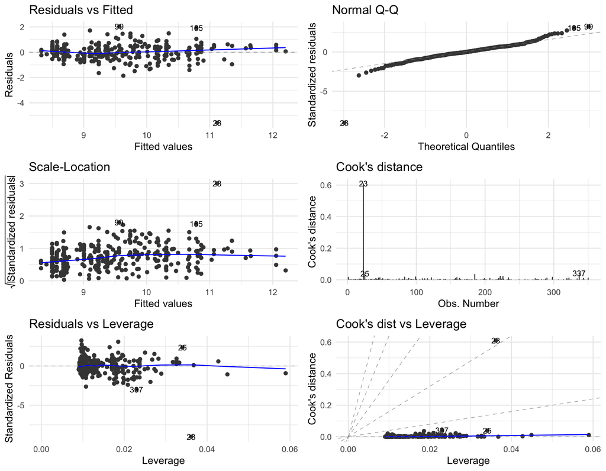

```r
library(ggfortify)
autoplot(mod_baseline_114, which = 1:6, ncol = 2, label.size = 3) + theme_minimal()
```

ℹ️ Diagnostic Mapping Guide

| Plot Number & Name | Target Trend / Ideal Behavior | Relevant Von Auer Assumption |
| --- | --- | --- |
| **(1) Residuals vs Fitted** | Flat, symmetric, evenly spread dots around the 0-line | **A2** (Linearity), **B2** (Homoscedasticity) |
| **(2) Normal Q-Q** | Points strictly tracking the diagonal line | **B4** (Normal Distribution of errors) |
| **(3) Scale-Location** | Horizontal line with constant vertical spread | **B2** (Homoscedasticity / Variance constancy) |
| **(4) Cook’s distance** | No extreme, towering spikes | **A3** (Parameter Constancy / Outlier detection) |
| **(5) Residuals vs Leverage** | Points clustered left; no points with high leverage | **C1 / A3** (Influential data points / Endogeneity check) |
| **(6) Cook’s dist vs Leverage** | Points remain safely within the critical Cook contours | **A3** (Stability of the estimated coefficients) |

**Important⚠️ T2: Formulate Your Own Diagnostic Readout**

Analyze the six charts above with your partner. Write down a one-sentence verdict for each of the following properties before unfolding the solution box:

1. Variance Constancy (B2): Does the residual spread remain stable across the entire range of fitted values? Is there visible heteroscedasticity? Where in the fitted-value range is the residual spread largest? (Hint: Evaluate Plots 1 and 3).
2. Error Distribution (B4): Do the error terms follow a gaussian bell curve, or do we see systematic deviations at the extremes (tail deviations)? (Hint: Evaluate Plot 2 with Q-Q residuals).
3. Influential Outliers (A3): Are there specific weeks (labeled observation numbers) that heavily distort or dominate the model’s parameters? Pay close attention to data points like “23”, “28”, and “105”.

Write a one-sentence verdict per plot and the associated assumption(s).

**Note🟢 Instructor’s Solution & Diagnostic Assessment (Click here)**

- A3 Assessment (Outliers): The observation for Week 28 stands out as an extreme outlier in almost all plots (3, 5, and 6). In Plot 4 (Cook’s distance), Week 23 also stands out significantly. These weeks have a high leverage effect and locally distort our $\hat{\beta}$ estimates.
- B2 Assessment: There is slight heteroscedasticity. In Plots 1 and 3, it is evident that the residuals cluster closer to the zero line at low estimated sales figures (Fitted Values < 9) than at medium values.
- B4 assessment: The Q-Q plot shows a so-called heavy-tailed distribution. On both the left and right edges, the points systematically deviate from the ideal straight line. The assumption of normally distributed error terms is empirically violated.

### 2.1.2 Moving from Visual Impressions to Formal Hypothesis Tests

To back our initial visual read with statistical rigor, we run formal hypothesis tests for Autocorrelation (**B3**) and Normality (**B4**). However, as *AI Value Creators*, we do not blindly accept p-values; we use them as starting points for deeper structural diagnostics.

```r
# 1. Formal Durbin-Watson Test for first-order autocorrelation (B3)
dw_result <- car::durbinWatsonTest(mod_baseline_114)
dw_result
```

```
 lag Autocorrelation D-W Statistic p-value
   1      0.06202227      1.860975   0.136
 Alternative hypothesis: rho != 0
```

```r
# 2. Formal Shapiro-Wilk Test for normality of residuals (B4)
sw_result <- shapiro.test(residuals(mod_baseline_114))
sw_result
```

```
    Shapiro-Wilk normality test

data:  residuals(mod_baseline_114)
W = 0.87904, p-value = 5.535e-16
```

**Important⚠️ T2b: The Statistical Paradox**

Look closely at the p-values from your live console output:

- Durbin-Watson: The DW statistic is 1.861 with a p-value of 0.136.
- Shapiro-Wilk: The W statistic is 0.879 with a p-value of 5.535e-16 (effectively zero).

Discuss with your fellow students:

1. Based on standard 0.05 thresholds, what are the formal verdicts for assumption B3 and assumption B4?
2. Why is the “clean” Durbin-Watson result highly surprising for weekly time-series panel data?

**Qualifying the B3 Result:** The ACF Diagnostic Plot

To investigate why our Durbin-Watson test indicates an absence of first-order autocorrelation, we analyze the Autocorrelation Function (ACF) plot. We pass the base R `acf` calculations directly into `autoplot()` to maintain a consistent `ggplot2` visualization layout.

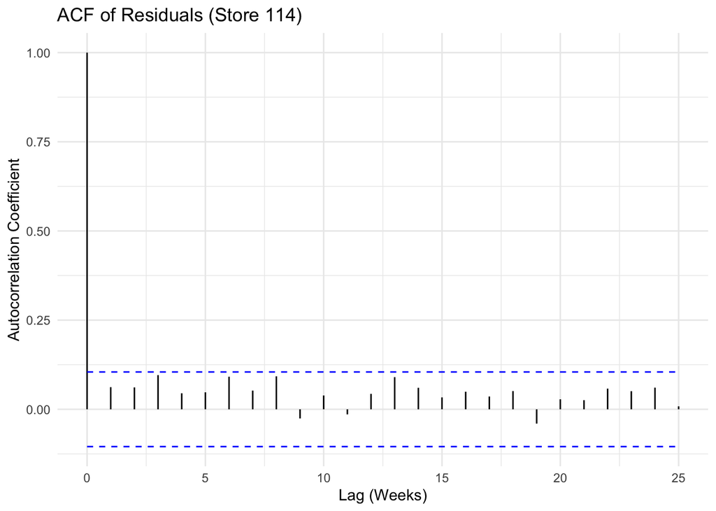

```r
# Visualizing residual dependencies across multiple time lags
autoplot(acf(residuals(mod_baseline_114), plot = FALSE)) +
  labs(title = "ACF of Residuals (Store 114)", x = "Lag (Weeks)", y = "Autocorrelation Coefficient") +
  theme_minimal()
```

**Important⚠️ T2c: Interpreting the Visual Proof**

Examine the ACF plot above.

1. Look at Lag 1 and higher lags. Do any of the vertical correlation spikes cross the blue dashed significance thresholds?
2. How does this visual result qualify and explain the Durbin-Watson test score? Bring in your domain knowledge about the model variables.

**Note🟢 Instructor Solution: Resolving the Paradox (Click to unfold)**

### 2.1.3 Checking for Multicollinearity

To verify the absence of severe multicollinearity (assumption **C2**), we examine the Variance Inflation Factors (VIF). Multicollinearity is fundamentally a technical/numerical problem: high correlation between predictors makes the matrix (X’X) nearly singular. This leads to numerical instability when inverting the matrix to compute the OLS coefficient estimates and causes inflated variances of the estimates.

```r
vif_baseline_114 <- car::vif(mod_baseline_114)
vif_baseline_114
```

```
               GVIF Df GVIF^(1/(2*Df))
feat       1.105878  1        1.051607
log(price) 2.508236  1        1.583741
brand      2.368140  2        1.240515
```

The maximum VIF in the baseline model for store 114 is **2.51**. Common rules of thumb suggest that VIF values below 5 are generally unproblematic, values between 5 and 10 warrant caution, and values above 10 indicate potentially severe multicollinearity. Our model lies comfortably below these thresholds.

**However**, low VIF values do not guarantee that the model specification is otherwise sound. In our case, the maximum VIF of 2.51 indicates that multicollinearity is **technically not a problem** — the matrix (X’X) is well-conditioned and the estimates are numerically stable. Nevertheless, even at this low level, the presence of moderate correlations between predictors can still serve as a helpful diagnostic signal, suggesting that we should examine the model specification more carefully. As Step 1b will clearly demonstrate, omitted relevant variables, incorrect functional form, or endogeneity can still lead to serious bias in the estimates even when multicollinearity is technically absent.

## 2.2 Step 1b: feat × deal interaction

As shown above, multicollinearity is technically not an issue in our baseline model. However, as data translators we should interpret the moderate correlation between advertising (`feat`) and the current price level (`log(price)`) as an important diagnostic hint that warrants closer inspection.

Why would advertising be systematically correlated with the shelf price? Domain knowledge gives us the answer: retailers rarely advertise a product at full price. They advertise *discounts*. This points directly to an **A1 violation (omitted variable)**. We modeled the advertising (`feat`), but we left out the operational trigger: the price promotion (`deal`).

Let us cross-tabulate `feat` and `deal` to see how deeply these two marketing levers are entangled in Store 114.

```r
tbl_114%>%
  count(feat, deal) %>%
  tidyr::complete(feat = 0:1, deal = 0:1, fill = list(n = 0)) %>%
  group_by(feat) %>%
  mutate(
    share_within_feat = n / sum(n),
    share_within_feat = scales::percent(share_within_feat, accuracy = 0.1)
  ) %>%
  ungroup() %>%
  mutate(
    feat = paste0("feat = ", feat),
    deal = paste0("deal = ", deal)
  ) %>%
  gt() %>%
  gt::tab_header(title = "feat × deal for Store 114") %>%
  gt::cols_label(
    feat = "Advertising",
    deal = "Price promotion",
    n = "Count",
    share_within_feat = "Share within feat"
  ) %>%
  gt::tab_options(table.font.size = "13px")
```

feat × deal for Store 114

| Advertising | Price promotion | Count | Share within feat |
| --- | --- | --- | --- |
| feat = 0 | deal = 0 | 167 | 62.3% |
| feat = 0 | deal = 1 | 101 | 37.7% |
| feat = 1 | deal = 0 | 0 | 0.0% |
| feat = 1 | deal = 1 | 83 | 100.0% |

**Tip💡 Why doesn’t a model with BOTH variables crash? (The asymmetric split)**

Looking at the table, `feat = 1` perfectly implies `deal = 1`. If we add `deal` to our regression, shouldn’t the model crash due to perfect multicollinearity (a C2 violation)?

Look at the `feat = 0` rows. When there is *no* advertising, the store still runs price promotions roughly 38% of the time (101 out of 268 weeks). This asymmetric variation is the model’s lifeline: 1. It learns the pure effect of a price drop (`deal`) from the weeks without advertising. 2. It estimates the `feat` coefficient as the *additional* boost that advertising provides *on top* of a deal.

But because `feat = 1` never exists without a deal, the model has to strictly assume that effects are simply additive. It has never actually seen advertising work on its own.

```r
tbl_114 %>%
  count(feat, deal) %>%
  pivot_wider(names_from = deal,
              values_from = n,
              names_prefix = "deal=",
              values_fill = 0) %>%
  gt() %>%
  gt::tab_header(title = "Joint distribution of feat and deal in Store 114") %>%
  gt::tab_options(table.font.size = "13px")
```

Joint distribution of feat and deal in Store 114

| feat | deal=0 | deal=1 |
| --- | --- | --- |
| 0 | 167 | 101 |
| 1 | 0 | 83 |

In every single week where Store 114 ran feature advertising (`feat = 1`), there was also a price promotion (`deal = 1`). Feature advertising never appears alone in the data.

**Warning⚠️ The A1 violation**

Our baseline model includes `feat` but not `deal`. If `feat = 1` always co-occurs with `deal = 1`, then the estimated `feat` coefficient absorbs **both** effects: the advertising effect *and* the deal effect.

This is the classic **omitted variable bias** (A1 violation). Through the domino effect, A1 violation produces a C1 violation (endogeneity): the omitted `deal` is now part of the error term, and it is correlated with `feat`.

### 2.2.1 What happens when we add `deal`?

```r
mod_full_114 <- lm(logmove ~ feat + deal + log(price) + brand, data = tbl_114)

mod_full_114 %>%
  tidy(conf.int = TRUE) %>%
  mutate(across(where(is.numeric), \(x) round(x, 3))) %>%
  gt() %>%
  gt::tab_options(table.font.size = "13px")
```

| term | estimate | std.error | statistic | p.value | conf.low | conf.high |
| --- | --- | --- | --- | --- | --- | --- |
| (Intercept) | 10.887 | 0.131 | 82.918 | 0.000 | 10.629 | 11.146 |
| feat | 0.791 | 0.093 | 8.506 | 0.000 | 0.608 | 0.974 |
| deal | 0.268 | 0.081 | 3.298 | 0.001 | 0.108 | 0.429 |
| log(price) | -2.728 | 0.196 | -13.946 | 0.000 | -3.113 | -2.343 |
| brandminute.maid | 0.253 | 0.095 | 2.664 | 0.008 | 0.066 | 0.439 |
| brandtropicana | 0.705 | 0.127 | 5.547 | 0.000 | 0.455 | 0.954 |

Comparing the two models on Store 114:

**Show code: coefficient comparison table**

```r
bind_rows(
  tidy(mod_baseline_114) %>% mutate(model = "Baseline (without deal)"),
  tidy(mod_full_114)  %>% mutate(model = "Full (with deal)")
) %>%
  filter(term %in% c("feat", "deal")) %>%
  select(model, term, estimate) %>%
  pivot_wider(names_from = term, values_from = estimate) %>%
  mutate(across(where(is.numeric), \(x) round(x, 3))) %>%
  gt() %>%
  gt::tab_options(table.font.size = "13px")
```

| model | feat | deal |
| --- | --- | --- |
| Baseline (without deal) | 0.935 | NA |
| Full (with deal) | 0.791 | 0.268 |

The `feat` coefficient drops from **0.935** (naïve baseline) to **0.791** (with `deal`). The difference of **0.145** log units is the empirical size of the omitted-variable bias.

**Important⚠️ T3: Interpret the OVB shift**

1. By how much does the `feat` coefficient change when `deal` is added to the model? (Read from the comparison table.)
2. What does this say about the (naïve) baseline estimate from Step 1a?
3. Could you, based on these data alone, tell Sarah what an advertising campaign **without** a deal would do? Why or why not?

Keep your notes — they go into the first translator memo at the end of the lab.

## 2.3 Step 1c — Does this generalise? Replication and the full panel

We have an OVB story for Store 114. Is this a peculiarity of Store 114, or is it a structural feature of the data? Two paths to find out:

1. **Replicate** in a second store
2. **Pool** all 83 stores

We start with the replication, because it brings out something that pooling would hide.

### 2.3.1 Replication in Store 83

We fit the same two models — baseline and full — on **Store 83**, a demographically different store.

```r
mod_baseline_83 <- lm(logmove ~ feat + log(price) + brand, data = tbl_83)
mod_full_83  <- lm(logmove ~ feat + deal + log(price) + brand, data = tbl_83)
```

**Show code: side-by-side comparison**

```r
bind_rows(
  tibble(store = "Store 114", model = "(naïve) baseline",     feat = coef(mod_baseline_114)["feat"]),
  tibble(store = "Store 114", model = "with deal", feat = coef(mod_full_114)["feat"]),
  tibble(store = "Store 83",  model = "(naïve) baseline",     feat = coef(mod_baseline_83)["feat"]),
  tibble(store = "Store 83",  model = "with deal", feat = coef(mod_full_83)["feat"])
) %>%
  pivot_wider(names_from = model, values_from = feat) %>%
  mutate(
    ovb_diff = `(naïve) baseline`- `with deal`,
    across(where(is.numeric), \(x) round(x, 3))
  ) %>%
  gt() %>%
  gt::tab_options(table.font.size = "13px")
```

| store | (naïve) baseline | with deal | ovb_diff |
| --- | --- | --- | --- |
| Store 114 | 0.935 | 0.791 | 0.145 |
| Store 83 | 1.073 | 1.101 | -0.028 |

In **Store 114** the OVB difference is **0.145** — positive, as expected from the theoretical argument.

In **Store 83** the OVB difference is **-0.028** — the sign **flips**. Adding `deal` does not reduce the `feat` coefficient here; it slightly increases it.

**Warning💥 Aha-moment: replication as a stress test**

Two stores from the same chain, same brands, same time window — and they tell different stories about how `feat` and `deal` interact **locally**. Within each store, classical inference gives a confident answer. Across stores, the answers do not match.

This is what **replication** is for. It is not a confirmation ritual. It is a stress test of external validity.

If we had only seen Store 114, we might have written Sarah a confident memo. Store 83 forces us to qualify it.

### 2.3.2 The full panel: what does pooling tell us?

When we fit the same models on **all 83 stores**, we get an average view that smooths over local heterogeneity.

```r
mod_baseline_full <- lm(logmove ~ feat + log(price) + brand, data = tbl_full)
mod_full_full  <- lm(logmove ~ feat + deal + log(price) + brand, data = tbl_full)
```

**Show code: full-panel comparison**

```r
tibble(
  scope    = c("Store 114 (n = 351)", "Store 83 (n = 333)", "Full panel (n ≈ 28k)"),
  feat_baseline = c(coef(mod_baseline_114)["feat"], coef(mod_baseline_83)["feat"], coef(mod_baseline_full)["feat"]),
  feat_full  = c(coef(mod_full_114)["feat"],  coef(mod_full_83)["feat"],  coef(mod_full_full)["feat"])
) %>%
  mutate(
    ovb_diff = feat_baseline - feat_full,
    across(where(is.numeric), \(x) round(x, 3))
  ) %>%
  gt() %>%
  gt::tab_options(table.font.size = "13px")
```

| scope | feat_baseline | feat_full | ovb_diff |
| --- | --- | --- | --- |
| Store 114 (n = 351) | 0.935 | 0.791 | 0.145 |
| Store 83 (n = 333) | 1.073 | 1.101 | -0.028 |
| Full panel (n ≈ 28k) | 0.879 | 0.841 | 0.038 |

In the full panel the OVB difference is **0.038**. The structural confounding is positive on average — but the local picture is heterogeneous.

**Show code: feat × deal in the full panel**

```r
tbl_full %>%
  count(feat, deal) %>%
  pivot_wider(names_from = deal,
              values_from = n,
              names_prefix = "deal=",
              values_fill = 0) %>%
  gt() %>%
  gt::tab_header(title = "feat × deal across all 83 stores") %>%
  gt::tab_options(table.font.size = "13px")
```

feat × deal across all 83 stores

| feat | deal=0 | deal=1 |
| --- | --- | --- |
| 0 | 12970 | 9310 |
| 1 | 0 | 6667 |

Globally, the structural rule is exact: **whenever `feat = 1`, `deal = 1`**. There is no week, in any store, where a brand was featured without also being on price promotion.

**Important⚠️ T4: Translator memo no. 1 (Question 1 — the advertising effect)**

Draft Sarah’s first memo. Cover:

- Can the historical data tell us what an advertising campaign *causes* in terms of sales?
- What is the methodological obstacle?
- What would be needed to answer her question properly?

**3–5 sentences, business language.** Bonus points if you mention what kind of **study design** would resolve the problem (forward reference to Lab 3).

# 3 Step 2 — The BLUE bridge becomes operative

We have hit a wall on Question 1. Classical inference delivers coefficients with tight confidence intervals — but we cannot interpret them causally, because the data foundation does not support it (A1 violated → C1 violated). And the replication in Store 83 shows that even within the chain, the local story changes.

Sarah’s **Question 2** is different. She wants a *prediction tool* for inventory planning. The question is not *“what would advertising cause?”*. It is *“what will sales be, given conditions we observe?”*.

For prediction, BLUE is not the right criterion.

**Note📚 Background: BLUE for inference vs. prediction**

Under the Gauss-Markov assumptions, OLS is the **B**est **L**inear **U**nbiased **E**stimator. Note the order: *first* unbiased, *then* minimum variance **among the unbiased**.

**For inference (explanation),** this is the gold standard. The coefficient should reflect the true effect — unbiasedness is essential.

**For prediction,** the criterion is different. What we want is *minimum total error on new data*:

$$\text{MSE}(\hat{Y}) = \text{Bias}^2(\hat{Y}) + \text{Var}(\hat{Y}) + \sigma_{\varepsilon}^2$$

In prediction, accepting *some* bias for *much less variance* can lower the total MSE. This is the rationale for regularised methods like Lasso and Ridge — they are *not* BLUE by design.

→ The same theoretical foundation explains both paths, with opposite optimality criteria. This is the **BLUE bridge**.

This conceptual shift sets up the rest of the lab. We assume the business-relevant relationships are **stable** for inventory planning purposes (this is a working assumption, not a guarantee — the Lucas critique applies if the system is later perturbed). Given that assumption, we now ask: **how well does the model generalise to stores we have not seen?**

# 4 Step 3 — Question 2 (Prediction): Out-of-Sample Evaluation

## 4.1 Step 3a — Train on Store 114, predict on Store 83

We use the same data we already have: train on our analytical sample (Store 114), evaluate the prediction error on the replication store (Store 83).

```r
pred_83  <- predict(mod_baseline_114, newdata = tbl_83)
rmse_83  <- sqrt(mean((pred_83 - tbl_83$logmove)^2))
rmse_114 <- sqrt(mean(residuals(mod_baseline_114)^2))
```

| Metric | RMSE on log-sales |
| --- | --- |
| In-sample (Store 114, baseline model) | 0.625 |
| Out-of-sample (Store 83 from Store 114) | 0.747 |

Given that `logmove` ranges roughly from 4 to 14, this is a non-trivial error. The out-of-sample value is meaningfully larger than the in-sample value — a first sign that performance on **unseen stores** is systematically worse than what the training data suggested.

## 4.2 Step 3b — Train/test split across stores

A single out-of-sample target store gives one number. To get a realistic estimate of generalisation error, we split the **set of stores** itself: 80 % of stores for training, 20 % for testing.

```r
set.seed(42)
stores_all  <- unique(tbl_full$store)
test_stores <- sample(stores_all, size = floor(0.20 * length(stores_all)))

tbl_train <- tbl_full %>% filter(!store %in% test_stores)
tbl_test  <- tbl_full %>% filter(store  %in% test_stores)

mod_train  <- lm(logmove ~ feat + log(price) + brand, data = tbl_train)
pred_test  <- predict(mod_train, newdata = tbl_test)

rmse_train <- sqrt(mean(residuals(mod_train)^2))
rmse_test  <- sqrt(mean((pred_test - tbl_test$logmove)^2))
```

| Metric | RMSE on log-sales |
| --- | --- |
| In-sample (training stores) | 0.712 |
| Out-of-sample (test stores) | 0.723 |

**Tip💡 Splitting across stores, not across weeks**

We split the **set of stores**, not the set of weeks. Splitting at the week level would mean the model has already seen the same store — predictive performance would be artificially inflated. For a prediction tool that should work *in new stores*, we need store-level splitting.

In time-series settings the same principle extends to **temporal CV** to avoid future-leakage. You will revisit this in ER017.

## 4.3 Step 3c — K-fold cross-validation

```r
set.seed(42)
K <- 5
stores_shuffled <- sample(unique(tbl_full$store))
folds <- cut(seq_along(stores_shuffled), breaks = K, labels = FALSE)

cv_rmses <- map_dbl(1:K, \(k) {
  test_st  <- stores_shuffled[folds == k]
  train_st <- stores_shuffled[folds != k]

  mod_k <- lm(logmove ~ feat + log(price) + brand,
              data = tbl_full %>% filter(store %in% train_st))
  pred_k   <- predict(mod_k,
                      newdata = tbl_full %>% filter(store %in% test_st))
  actual_k <- tbl_full %>% filter(store %in% test_st) %>% pull(logmove)
  sqrt(mean((pred_k - actual_k)^2))
})

cv_score <- mean(cv_rmses)
```

The five fold-wise RMSEs are **0.728, 0.699, 0.738, 0.696, 0.721**. The mean of these gives our cross-validated estimate of out-of-sample error:

| Quantity | Value |
| --- | --- |
| Mean 5-fold CV-RMSE | 0.716 |

This is the realistic generalisation-error estimate for the simple model `feat + log(price) + brand` on a new store.

**Important⚠️ T5: Translator memo no. 2 (Question 2 — the prediction tool)**

Draft Sarah’s second memo. Cover:

- Can we deliver an inventory-planning tool that works across all 83 stores?
- What is the realistic out-of-sample accuracy (CV-RMSE ≈ 0.72)?
- What variables are *not yet* in the model that you would add to improve it? (Hint: think about what makes Store 83 different from Store 114.)

# 5 Step 4 — Synthesis

| Question | Methodological path | Verdict |
| --- | --- | --- |
| 1. Effect of a Q4 advertising campaign | Path B: causal identification | Not answerable from these data alone |
| 2. Inventory prediction tool | Path A: out-of-sample, CV | Deliverable, with caveats |

The same dataset gave us two methodological operations and two different verdicts. **This is the BLUE bridge in action:**

- Path A (prediction): we accept that we cannot disentangle advertising from price promotion, because for *forecasting under stable structure* that does not matter. The relationship is consistent in the data, and the model predicts.
- Path B (explanation/intervention): we cannot deliver a causal claim, because the data foundation does not support identification. To answer Sarah’s Q1 properly, we need a different study design — an A/B test (forward reference to Lab 3).

This is the **central lesson of the lab**: the optimality criterion depends on the question. Same data, two operations, two answers.

**Note📚 Background: Lucas critique**

This is the deeper reason why Sarah’s Q1 is fundamentally different from Q2: it asks about a *change* to the system, not about predicting within it. Path A is appropriate when the system stays as it is. Path B is required when we change the system.

**Note📚 Background: Big data is not population**

Even when we use all 83 stores, we have not “reached population”. These data come from **one** supermarket chain, in **one** city, during **one** time period (1989–1994), with **one** selected set of brands. Inferring from this dataset to “supermarket markets in general” is an extra-statistical generalisation.

Big data does not dissolve the population/sample distinction — it just makes the sample large. The Lucas critique and external-validity arguments still apply.

# 6 Bonus — For independent study

Lab 2 will refine the prediction tool by adding the 12 demographic variables from `tbl_demo`. As preparation, you can explore:

**Important⚠️ B1 (Bonus): Lasso preview on demographics**

Join the demographics to the full panel and fit a Lasso model with cross-validation:

```r
library(glmnet)
tbl_joined <- tbl_full %>%
  left_join(tbl_demo, by = "store")
# build the design matrix, then:
# cv_fit <- cv.glmnet(X, y, alpha = 1)
```

Which demographic variables survive at the optimal $\lambda$? How does the cross-validated RMSE compare to the simple model from Step 3?

This is exactly the question we will work through together in Lab 2. Coming with your own attempt makes the lab more useful.

# 7 What comes next

| Lab | Question it answers |
| --- | --- |
| **Lab 2 — Regularisation on demographics** | Can we improve the prediction tool by adding demographic variables — and which of them matter? |
| **Lab 3 — A/B-test design** | How would we set up a study that answers Sarah’s Question 1 properly? |

### 7.0.1 The full panel: exact rule or strong tendency?

When we move from one store to all 83 stores, we should again verify the empirical relationship instead of assuming it.

```r
tbl_full %>%
  count(feat, deal) %>%
  tidyr::complete(feat = 0:1, deal = 0:1, fill = list(n = 0)) %>%
  group_by(feat) %>%
  mutate(
    share_within_feat = n / sum(n),
    share_within_feat = scales::percent(share_within_feat, accuracy = 0.1)
  ) %>%
  ungroup() %>%
  mutate(
    feat = paste0("feat = ", feat),
    deal = paste0("deal = ", deal)
  ) %>%
  gt() %>%
  gt::tab_header(title = "feat × deal across all 83 stores") %>%
  gt::cols_label(
    feat = "Advertising",
    deal = "Price promotion",
    n = "Count",
    share_within_feat = "Share within feat"
  ) %>%
  gt::tab_options(table.font.size = "13px")
```

feat × deal across all 83 stores

| Advertising | Price promotion | Count | Share within feat |
| --- | --- | --- | --- |
| feat = 0 | deal = 0 | 12970 | 58.2% |
| feat = 0 | deal = 1 | 9310 | 41.8% |
| feat = 1 | deal = 0 | 0 | 0.0% |
| feat = 1 | deal = 1 | 6667 | 100.0% |

```r
tbl_full %>%
  summarise(
    `# obs`                  = n(),
    `# feat = 1`             = sum(feat == 1, na.rm = TRUE),
    `# deal = 1`             = sum(deal == 1, na.rm = TRUE),
    `# feat = 1 & deal = 1`  = sum(feat == 1 & deal == 1, na.rm = TRUE),
    `# feat = 1 & deal = 0`  = sum(feat == 1 & deal == 0, na.rm = TRUE),
    `P(deal = 1 | feat = 1)` = ifelse(sum(feat == 1, na.rm = TRUE) > 0,
                                      sum(feat == 1 & deal == 1, na.rm = TRUE) /
                                      sum(feat == 1, na.rm = TRUE),
                                      NA_real_)
  ) %>%
  mutate(`P(deal = 1 | feat = 1)` = scales::percent(`P(deal = 1 | feat = 1)`,
                                                    accuracy = 0.1)) %>%
  gt() %>%
  gt::tab_header(title = "How close is the full panel to feat => deal?") %>%
  gt::tab_options(table.font.size = "13px")
```

How close is the full panel to feat => deal?

| # obs | # feat = 1 | # deal = 1 | # feat = 1 & deal = 1 | # feat = 1 & deal = 0 | P(deal = 1 \| feat = 1) |
| --- | --- | --- | --- | --- | --- |
| 28947 | 6667 | 15977 | 6667 | 0 | 100.0% |

**Show code: stores with feature-without-deal cases**

```r
tbl_full %>%
  group_by(store) %>%
  summarise(
    n_feat = sum(feat == 1, na.rm = TRUE),
    n_feat_without_deal = sum(feat == 1 & deal == 0, na.rm = TRUE),
    p_deal_given_feat = ifelse(n_feat > 0,
                               sum(feat == 1 & deal == 1, na.rm = TRUE) / n_feat,
                               NA_real_)
  ) %>%
  ungroup() %>%
  filter(n_feat > 0) %>%
  arrange(desc(n_feat_without_deal), p_deal_given_feat) %>%
  mutate(
    p_deal_given_feat = scales::percent(p_deal_given_feat, accuracy = 0.1)
  ) %>%
  gt() %>%
  gt::tab_header(title = "Store-level dependence between feature and deal") %>%
  gt::cols_label(
    n_feat = "# feat = 1",
    n_feat_without_deal = "# feat = 1 & deal = 0",
    p_deal_given_feat = "P(deal = 1 | feat = 1)"
  ) %>%
  gt::tab_options(table.font.size = "13px")
```

Store-level dependence between feature and deal

| store | # feat = 1 | # feat = 1 & deal = 0 | P(deal = 1 \| feat = 1) |
| --- | --- | --- | --- |
| 2 | 75 | 0 | 100.0% |
| 5 | 79 | 0 | 100.0% |
| 8 | 82 | 0 | 100.0% |
| 9 | 81 | 0 | 100.0% |
| 12 | 79 | 0 | 100.0% |
| 14 | 81 | 0 | 100.0% |
| 18 | 78 | 0 | 100.0% |
| 21 | 81 | 0 | 100.0% |
| 28 | 82 | 0 | 100.0% |
| 32 | 83 | 0 | 100.0% |
| 33 | 83 | 0 | 100.0% |
| 40 | 78 | 0 | 100.0% |
| 44 | 80 | 0 | 100.0% |
| 45 | 82 | 0 | 100.0% |
| 47 | 76 | 0 | 100.0% |
| 48 | 81 | 0 | 100.0% |
| 49 | 79 | 0 | 100.0% |
| 50 | 80 | 0 | 100.0% |
| 51 | 73 | 0 | 100.0% |
| 52 | 81 | 0 | 100.0% |
| 53 | 84 | 0 | 100.0% |
| 54 | 84 | 0 | 100.0% |
| 56 | 81 | 0 | 100.0% |
| 59 | 80 | 0 | 100.0% |
| 62 | 81 | 0 | 100.0% |
| 64 | 71 | 0 | 100.0% |
| 67 | 82 | 0 | 100.0% |
| 68 | 79 | 0 | 100.0% |
| 70 | 83 | 0 | 100.0% |
| 71 | 80 | 0 | 100.0% |

[output cut: 53 more lines]

## References

Auer, Ludwig von. 2023. *Ökonometrie: Eine Einführung*. 8th ed. Wiesbaden: Springer Gabler.